# Predicting NBA Hall of Fame Status

##### CMSC422 Final Project

##### Fall 2022 Teli

Group Members: Prakhar Gupta, Andrew Zhong, Hari Shanmugaraja, Rohit Pasumarthi

## Introduction and Motivation

The Naismith Memorial Hall of Fame is an honor bestowed upon Basketball players, coaches, and staff that have had exceptional careers or contributions to the game of basketball. In the project, we set out to create predictive models to determine the likelihood of current NBA players achieving Hall of Fame status. We specifically wanted to focus on prediction for players that are currently active or have only recently retired, as they would not be eligible for the award yet. By using statistical models, we are able to gain a less subjective perspective on who belongs in the Hall of Fame, as human decision-making may be swayed by factors such as flashiness or player fame. We hope that the model will be able to highlight players that are deserving of Hall of Fame status, despite not always being in the spotlight or being the most popular players on the most successful teams. Besides using these predictions as a barometer for a players’ greatness (that may otherwise have been passed up due to public popularity), models like these can also be used for more serious reasons, such as for companies to decide which players will be a better bet to sponsor after retirement. We wanted to compare how different models performed against this task, as well as how different models would weight each attribute differently, which would result in different top predictions for Hall of Famers.

[figure not shown]

```python
import numpy as np, pandas as pd, seaborn as sns
from sklearn.svm import SVC
from sklearn.model_selection import train_test_split
from matplotlib import pyplot as plt
```

We import our data from sports-reference.com and barttorvik.com. We use two sources to ensure that we can fill in as much missing data as possible.

`player_data.csv` and `Players.csv` combine to provide us general player data, such as height, weight, college, birth year, and position. `Season_Stats.csv` includes data on players' performances during any given season.

```python
player_data = pd.read_csv('player_data.csv')
players = pd.read_csv('Players.csv')
seasons_stats = pd.read_csv('Seasons_Stats.csv')
```

```python
player_data.head()
```

|  | name | year_start | year_end | position | height | weight | birth_date | college |
| --- | --- | --- | --- | --- | --- | --- | --- | --- |
| 0 | Alaa Abdelnaby | 1991 | 1995 | F-C | 6-10 | 240.0 | June 24, 1968 | Duke University |
| 1 | Zaid Abdul-Aziz | 1969 | 1978 | C-F | 6-9 | 235.0 | April 7, 1946 | Iowa State University |
| 2 | Kareem Abdul-Jabbar | 1970 | 1989 | C | 7-2 | 225.0 | April 16, 1947 | University of California, Los Angeles |
| 3 | Mahmoud Abdul-Rauf | 1991 | 2001 | G | 6-1 | 162.0 | March 9, 1969 | Louisiana State University |
| 4 | Tariq Abdul-Wahad | 1998 | 2003 | F | 6-6 | 223.0 | November 3, 1974 | San Jose State University |

```python
players.head()
```

|  | Unnamed: 0 | Player | height | weight | collage | born | birth_city | birth_state |
| --- | --- | --- | --- | --- | --- | --- | --- | --- |
| 0 | 0 | Curly Armstrong | 180.0 | 77.0 | Indiana University | 1918.0 | NaN | NaN |
| 1 | 1 | Cliff Barker | 188.0 | 83.0 | University of Kentucky | 1921.0 | Yorktown | Indiana |
| 2 | 2 | Leo Barnhorst | 193.0 | 86.0 | University of Notre Dame | 1924.0 | NaN | NaN |
| 3 | 3 | Ed Bartels | 196.0 | 88.0 | North Carolina State University | 1925.0 | NaN | NaN |
| 4 | 4 | Ralph Beard | 178.0 | 79.0 | University of Kentucky | 1927.0 | Hardinsburg | Kentucky |

```python
seasons_stats.head()
```

|  | Unnamed: 0 | Year | Player | Pos | Age | Tm | G | GS | MP | PER | ... | FT% | ORB | DRB | TRB | AST | STL | BLK | TOV | PF | PTS |
| --- | --- | --- | --- | --- | --- | --- | --- | --- | --- | --- | --- | --- | --- | --- | --- | --- | --- | --- | --- | --- | --- |
| 0 | 0 | 1950.0 | Curly Armstrong | G-F | 31.0 | FTW | 63.0 | NaN | NaN | NaN | ... | 0.705 | NaN | NaN | NaN | 176.0 | NaN | NaN | NaN | 217.0 | 458.0 |
| 1 | 1 | 1950.0 | Cliff Barker | SG | 29.0 | INO | 49.0 | NaN | NaN | NaN | ... | 0.708 | NaN | NaN | NaN | 109.0 | NaN | NaN | NaN | 99.0 | 279.0 |
| 2 | 2 | 1950.0 | Leo Barnhorst | SF | 25.0 | CHS | 67.0 | NaN | NaN | NaN | ... | 0.698 | NaN | NaN | NaN | 140.0 | NaN | NaN | NaN | 192.0 | 438.0 |
| 3 | 3 | 1950.0 | Ed Bartels | F | 24.0 | TOT | 15.0 | NaN | NaN | NaN | ... | 0.559 | NaN | NaN | NaN | 20.0 | NaN | NaN | NaN | 29.0 | 63.0 |
| 4 | 4 | 1950.0 | Ed Bartels | F | 24.0 | DNN | 13.0 | NaN | NaN | NaN | ... | 0.548 | NaN | NaN | NaN | 20.0 | NaN | NaN | NaN | 27.0 | 59.0 |

5 rows × 53 columns

### Data Cleanup

```python
no_player_filter = ~seasons_stats.Player.isnull()
seasons_stats = seasons_stats[no_player_filter]
```

```python
players = players.rename(columns = {'Unnamed: 0':'id'})
```

We discovered that there are several distinct players who have the same name as another player. Below, we count the number of rows (players) grouped by name, which returns the number of occurences of each name in `player_data`.

```python
name_freq = player_data.groupby('name').count()

# Pandas creates too many columns, so we just take the first 2
name_freq = name_freq.iloc[:,:1]
name_freq = name_freq.reset_index()
name_freq.columns = ['Player Name', 'Frequency']

# We filter out all rows besides those representing duplicate names
dup_filter = name_freq['Frequency'] > 1
name_freq[dup_filter].head()
```

|  | Player Name | Frequency |
| --- | --- | --- |
| 314 | Bill Bradley | 2 |
| 420 | Bob Duffy | 2 |
| 494 | Bobby Jones | 2 |
| 505 | Bobby Wilson | 2 |
| 680 | Cedric Henderson | 2 |

In order to handle this and ensure we keep player data separate, we add a player id column to ensure that each player has a unique identifier.

```python
player_data['id'] = player_data.index
```

We also added a year born column. When computing this from the `seasons_stats` table we notice that when calculating age by year of play - age for that year, the answers we get are 1 off. Below, we compute the birth year of Michael Jordan and get the year 1964 as our result. If you are an extremely big fan or make a quick Google search, we find that MJ's real birthyear is 1963. This is likely due to the statistics websites taking age at the start of the year, before players have had the chance for their birthdays to pass.

```python
mj_stats = seasons_stats[seasons_stats.Player == 'Michael Jordan*']
mj_stats['Year'].iloc[0] - mj_stats['Age'].iloc[0]
```

```
1964.0
```

Therefore, we adjust all years born entries down by 1.

```python
seasons_stats['born'] = seasons_stats['Year'] - seasons_stats['Age'] - 1
```

We now use birth year and player name to join all data, throwing out any records where player born data is missing.

```python
born_missing_filter = ~players.born.isnull()
players = players[born_missing_filter]

born_missing_filter2 = ~player_data.birth_date.isnull()
player_data = player_data[born_missing_filter2]
```

```python
# Create key of player name and year born with which to join data
players_born = players[['Player', 'born']]

for i, row in player_data.iterrows():
    player_data.loc[i, 'born'] = float(row['birth_date'].split(',')[1])

player_data_born = player_data[['name', 'born']]
player_data_born.columns = ['Player', 'born']

born = pd.concat([players_born, player_data_born]).drop_duplicates()

# Create id column
born['id'] = born.index
```

There were two incorrect birthyears which had to be manually fixed.

```python
hakeem_id = born[born.Player == 'Hakeem Olajuwon*'].id.values[0]
born.loc[hakeem_id, 'born'] = 1962

magic_id = born[born.Player == 'Magic Johnson*'].id.values[0]
born.loc[magic_id, 'born'] = 1959
```

Here, we merge the data on our player name, year born key `['Player', 'born']` and remove existing aggregate entries.

```python
data = seasons_stats.merge(born, on=['Player', 'born'])

data = data[data.Tm != 'TOT']
```

Here we count the number of seasons that an individual player has played and then add that to the data

```python
data_season =  data[['id', 'Player', 'Year']].drop_duplicates()
data_season['season']  = data_season.groupby(['id', 'Player']).cumcount() + 1

#we merge this with our original data
data = data.merge(data_season, on=['id', 'Player', 'Year'])
```

We now perform some feature engineering to produce new features that we strongly believe could be related to HOF status, such as average per-game performance, MVP awards, and championships.

```python
#Extra stats to look at in data
data['PPG'] = data['PTS'] / data['G']
data['APG'] = data['AST'] / data['G']
data['RPG'] = data['TRB'] / data['G']
data['SPG'] = data['STL'] / data['G']
data['BPG'] = data['BLK'] / data['G']

# Adding mvps in case this also increases chance of being a Hall of Famer
mvp_players = {'Bob Pettit*': [1956, 1959],
                  'Bob Cousy*': [1957],
                  'Bill Russell*': [1958, 1961, 1962, 1963, 1965],
                  'Wilt Chamberlain*': [1960, 1966, 1967, 1968],
                  'Oscar Robertson*': [1964],
                  'Wes Unseld*': [1969],
                  'Willis Reed*': [1970],
                  'Kareem Abdul-Jabbar*': [1971, 1972, 1974, 1976, 1977, 1980],
                  'Dave Cowens*': [1973],
                  'Bob McAdoo*': [1975],
                  'Bill Walton*': [1978],
                  'Moses Malone*': [1979, 1982, 1983],
                  'Julius Erving*': [1981],
                  'Larry Bird*': [1984, 1985, 1986],
                  'Magic Johnson*': [1987, 1989, 1990],
                  'Michael Jordan*': [1988, 1991, 1992, 1996, 1998],
                  'Charles Barkley*': [1993],
                  'Hakeem Olajuwon*': [1994],
                  'David Robinson*': [1995],
                  'Karl Malone*': [1997, 1999],
                  'Shaquille O\'Neal*': [2000],
                  'Allen Iverson*': [2001],
                  'Tim Duncan': [2002, 2003],
                  'Kevin Garnett': [2004],
                  'Steve Nash': [2005, 2006],
                  'Dirk Nowitzki': [2007],
                  'Kobe Bryant': [2008],
                  'LeBron James': [2009, 2010, 2012, 2013],
                  'Derrick Rose': [2011],
                  'Kevin Durant': [2014],
                  'Stephen Curry': [2015, 2016],
                  'Russell Westbrook': [2017],
                  'James Harden': [2018]}

data['MVP'] = 0
for i, row in data.iterrows():
    for k, v in mvp_players.items():
        for year in v:
            if row['Player'] != k:
                break
            elif(row['Year'] == year) & (row['Player'] == k):
                data.loc[i, 'MVP'] = 1
                break
```

```python
# Adding nba champions in case this also increases chance of being a Hall of Famer
teams_champions = {'BOS': [1957, 1959, 1960, 1961, 1962, 1963, 1964, 1965, 1966, 1968, 1969, 1974, 1976, 1981, 1984, 1986, 2008],
                  'LAL': [1972, 1980, 1982, 1985, 1987, 1988, 2000, 2001, 2002, 2009, 2010],
                  'MNL': [1949, 1950, 1952, 1953, 1954],
                  'CHI': [1991, 1992, 1993, 1996, 1997, 1998],
                  'GSW': [1975, 2015, 2017, 2018],
                  'PHW': [1947, 1956],
                  'SAS': [1999, 2003, 2005, 2007, 2014],
                  'DET': [1989, 1990, 2004],
                  'MIA': [2006, 2012, 2013],
                  'PHI': [1967, 1983],
                  'SYR': [1955],
                  'HOU': [1994, 1995],
                  'NYK': [1970, 1973],
                  'STL': [1958],
                  'BLB': [1948],
                  'CLE': [2016],
                  'DAL': [2011],
                  'MIL': [1971],
                  'SEA': [1979],
                  'POR': [1977],
                  'ROC': [1951],
                  'WSB': [1978]}

data['Champion'] = 0
for i, row in data.iterrows():
    for k, v in teams_champions.items():
        for year in v:
            if row['Tm'] != k:
                break
            elif(row['Year'] == year) & (row['Tm'] == k):
                data.loc[i, 'Champion'] = 1
                break
```

Finally, we want to filter out players that don't achieve at least a certain amount of playing time in a season, as we consider them to not have enough data to be helpful.

```python
# Filter players with at least 800 min in a season
MIN_PLAYTIME = 800

playtime_filter = data.MP > MIN_PLAYTIME
hall_of_fame = data[playtime_filter]

#Create a function so that we can make a column in data, so that it is easier to if a player is in the Hall of Fame
def is_hof(x):
    return '*' in x

hall_of_fame['HOF'] = hall_of_fame['Player'].apply(is_hof)
```

```python
# Season 1973 - 1974 : start to count Steals, Blocks and BPM
recency_filter = hall_of_fame.Year >= 1974
hall_of_fame = hall_of_fame[recency_filter]

mvps = data[['id', 'Player', 'MVP']]
mvps['Nb_MVP'] = mvps.groupby('id').cumsum()
mvps = mvps.groupby(['id', 'Player'], sort=False)['Nb_MVP'].max().reset_index()

mvps.sort_values(by='Nb_MVP', ascending=False).head(10)
```

|  | id | Player | Nb_MVP |
| --- | --- | --- | --- |
| 707 | 789 | Kareem Abdul-Jabbar* | 6 |
| 1509 | 1675 | Michael Jordan* | 5 |
| 386 | 438 | Bill Russell* | 5 |
| 2681 | 2944 | LeBron James | 4 |
| 2350 | 494 | Gerald Brown | 4 |
| 437 | 494 | Wilt Chamberlain* | 4 |
| 1061 | 1185 | Moses Malone* | 3 |
| 1222 | 1366 | Magic Johnson* | 3 |
| 1199 | 1341 | Larry Bird* | 3 |
| 1566 | 1737 | Karl Malone* | 2 |

```python
champions = data[['id', 'Player', 'Champion']]
champions['Total_Champion'] = champions.groupby('id').cumsum()
champions = champions.groupby(['id', 'Player'], sort=False)['Total_Champion'].max().reset_index()
champions.sort_values(by='Total_Champion', ascending=False).head(10)
```

|  | id | Player | Total_Champion |
| --- | --- | --- | --- |
| 386 | 438 | Bill Russell* | 11 |
| 399 | 453 | Sam Jones* | 10 |
| 424 | 480 | K.C. Jones* | 8 |
| 466 | 526 | Tom Sanders* | 8 |
| 514 | 578 | John Havlicek* | 8 |
| 377 | 427 | Tom Heinsohn* | 8 |
| 1989 | 2203 | Robert Horry | 7 |
| 356 | 405 | Jim Loscutoff | 7 |
| 335 | 380 | Frank Ramsey* | 7 |
| 206 | 233 | Bob Cousy* | 6 |

```python
nb_seasons = data_season[['id', 'Player', 'season']]
nb_seasons = nb_seasons.groupby(['id', 'Player'], sort=False)['season'].max().reset_index()
nb_seasons.sort_values(by='season', ascending=False).head(10)
```

|  | id | Player | season |
| --- | --- | --- | --- |
| 1536 | 4426 | Kevin Willis | 21 |
| 1070 | 1195 | Robert Parish* | 21 |
| 2170 | 2401 | Kevin Garnett | 21 |
| 2224 | 2456 | Kobe Bryant | 20 |
| 707 | 789 | Kareem Abdul-Jabbar* | 20 |
| 1575 | 1747 | Charles Oakley | 19 |
| 1116 | 1248 | James Edwards | 19 |
| 1566 | 1737 | Karl Malone* | 19 |
| 2388 | 2630 | Paul Pierce | 19 |
| 1061 | 1185 | Moses Malone* | 19 |

```python
last_season = hall_of_fame[['id', 'Player', 'Year']]
last_season = last_season.groupby(['id', 'Player'], sort=False)['Year'].max().reset_index()
last_season.columns = ['id', 'Player', 'Last_Season']

total_points = data[['Player', 'PTS', 'id']].groupby(['id', 'Player']).sum()
total_points = total_points.reset_index()
total_points.columns = ['id', 'Player', 'Total_PTS']
```

```python
career = hall_of_fame.groupby(['id', 'Player']).mean()
career = career.reset_index()
career.head()
```

|  | id | Player | Unnamed: 0 | Year | Age | G | GS | MP | PER | TS% | ... | born | season | PPG | APG | RPG | SPG | BPG | MVP | Champion | HOF |
| --- | --- | --- | --- | --- | --- | --- | --- | --- | --- | --- | --- | --- | --- | --- | --- | --- | --- | --- | --- | --- | --- |
| 0 | 3 | Mahmoud Abdul-Rauf | 11386.142857 | 1994.000000 | 24.000000 | 73.428571 | 48.000000 | 2087.428571 | 15.242857 | 0.507857 | ... | 1969.0 | 4.000000 | 15.777782 | 3.880602 | 2.002227 | 0.907202 | 0.084110 | 0.0 | 0.000000 | 0.0 |
| 1 | 44 | Courtney Alexander | 15496.666667 | 2002.000000 | 24.000000 | 49.666667 | 17.666667 | 1198.333333 | 12.366667 | 0.499667 | ... | 1977.0 | 2.000000 | 11.563592 | 1.417068 | 2.464566 | 0.722924 | 0.096661 | 0.0 | 0.000000 | 0.0 |
| 2 | 58 | Ray Allen | 17385.052632 | 2005.368421 | 29.368421 | 68.421053 | 60.473684 | 2439.157895 | 18.526316 | 0.581474 | ... | 1975.0 | 9.368421 | 19.124945 | 3.452787 | 4.118728 | 1.137763 | 0.185133 | 0.0 | 0.105263 | 0.0 |
| 3 | 74 | David Andersen | 19934.000000 | 2010.000000 | 29.000000 | 63.000000 | 0.000000 | 891.000000 | 12.100000 | 0.497000 | ... | 1980.0 | 1.000000 | 5.825397 | 0.698413 | 3.301587 | 0.238095 | 0.190476 | 0.0 | 0.000000 | 0.0 |
| 4 | 146 | D.J. Augustin | 21501.375000 | 2012.625000 | 24.625000 | 68.875000 | 23.625000 | 1681.625000 | 13.837500 | 0.537250 | ... | 1987.0 | 4.625000 | 10.214707 | 4.143085 | 1.836157 | 0.607843 | 0.035776 | 0.0 | 0.000000 | 0.0 |

5 rows × 62 columns

```python
career_num = career[['id', 'Player', 'PER', 'TS%', 'OWS', 'DWS',
                     'WS', 'WS/48', 'OBPM', 'DBPM', 'BPM',
                     'FG%', '3P%', '2P%', 'eFG%', 'FT%',
                     'PPG', 'APG', 'RPG', 'SPG', 'BPG', 'HOF']]

career_num = career_num.merge(mvps, on=['id', 'Player'])
career_num = career_num.merge(champions, on=['id', 'Player'])
career_num = career_num.merge(nb_seasons, on=['id', 'Player'])
career_num = career_num.merge(last_season, on=['id', 'Player'])
career_num = career_num.merge(total_points, on=['id', 'Player'])

career_num.head()
```

|  | id | Player | PER | TS% | OWS | DWS | WS | WS/48 | OBPM | DBPM | ... | APG | RPG | SPG | BPG | HOF | Nb_MVP | Total_Champion | season | Last_Season | Total_PTS |
| --- | --- | --- | --- | --- | --- | --- | --- | --- | --- | --- | --- | --- | --- | --- | --- | --- | --- | --- | --- | --- | --- |
| 0 | 3 | Mahmoud Abdul-Rauf | 15.242857 | 0.507857 | 2.385714 | 1.171429 | 3.528571 | 0.072714 | 0.800000 | -3.057143 | ... | 3.880602 | 2.002227 | 0.907202 | 0.084110 | 0.0 | 0 | 0 | 9 | 1997.0 | 8553.0 |
| 1 | 44 | Courtney Alexander | 12.366667 | 0.499667 | 0.866667 | 0.566667 | 1.400000 | 0.056000 | -1.333333 | -2.266667 | ... | 1.417068 | 2.464566 | 0.722924 | 0.096661 | 0.0 | 0 | 0 | 3 | 2003.0 | 1690.0 |
| 2 | 58 | Ray Allen | 18.526316 | 0.581474 | 5.873684 | 1.757895 | 7.642105 | 0.149263 | 4.205263 | -1.247368 | ... | 3.452787 | 4.118728 | 1.137763 | 0.185133 | 0.0 | 0 | 2 | 18 | 2014.0 | 24505.0 |
| 3 | 74 | David Andersen | 12.100000 | 0.497000 | 0.400000 | 0.900000 | 1.300000 | 0.070000 | -2.500000 | -1.300000 | ... | 0.698413 | 3.301587 | 0.238095 | 0.190476 | 0.0 | 0 | 0 | 2 | 2010.0 | 501.0 |
| 4 | 146 | D.J. Augustin | 13.837500 | 0.537250 | 2.300000 | 1.162500 | 3.437500 | 0.094500 | 0.812500 | -2.625000 | ... | 4.143085 | 1.836157 | 0.607843 | 0.035776 | 0.0 | 0 | 0 | 9 | 2017.0 | 6214.0 |

5 rows × 27 columns

```python
career_num = career_num.fillna(0)

career_num = career_num.drop(['Player'], axis=1)
```

```python
# Looking at the features correlations with HOF
career_num.corr()['HOF'].sort_values(ascending=False)
```

```
HOF               1.000000
Total_PTS         0.471363
WS                0.389546
PPG               0.365606
OWS               0.354728
PER               0.323333
DWS               0.315797
Nb_MVP            0.315343
BPM               0.290873
WS/48             0.285238
Total_Champion    0.280929
OBPM              0.277936
season            0.240575
RPG               0.234286
SPG               0.204839
APG               0.202173
BPG               0.166891
FG%               0.135673
TS%               0.120102
2P%               0.095232
DBPM              0.088586
FT%               0.074549
eFG%              0.059544
3P%              -0.089724
Last_Season      -0.172186
id               -0.224112
Name: HOF, dtype: float64
```

# Predicion Models

Now that we are done setting up our dataset, we can train various models to predict future hall of fame status for current NBA players, as well as compare how well different models perform against each other. First, we will split our data into training and inference datasets. We only consider players that have been eligible for hall of fame status for long enough or have already achieved hall of fame status to be suitable training data, as otherwise we may get players that have retired recently and are hall of fame-worthy but just haven't had the chance to receive the honor yet. Our inference data is only players that are currently still active or have retired recently and have not yet had the chance to receive hall of fame status.

We then use sklearn's train_test_split function: https://scikit-learn.org/stable/modules/generated/sklearn.model_selection.train_test_split.html to split our train dataset into train and test subsections for model evaluation purposes.

```python
train = career_num[(career_num.Last_Season <= 1997) | (career_num.HOF == 1)]
test = career_num[(career_num.Last_Season > 1997) & (career_num.HOF == 0)]

X = train.drop('HOF', axis=1)
y = train['HOF']

X_train, X_test, y_train, y_test = train_test_split(X, y, test_size=0.2, random_state=0)

X_infer = test.drop('HOF', axis=1)
```

## SVM

```python
svm = SVC(kernel='linear', probability=True)
svm.fit(X_train, y_train)
```

```
SVC(kernel='linear', probability=True)
```

```python
print(f"The SVM achieved {svm.score(X_train, y_train) * 100}% accuracy on the train dataset and {svm.score(X_test, y_test) * 100}% accuracy on the test dataset.")
```

```
The SVM achieved 94.6843853820598% accuracy on the train dataset and 94.70198675496688% accuracy on the test dataset.
```

```python
svm_pred_proba = svm.predict_proba(X_infer)
svm_y_pred_proba = []
for i in enumerate(svm_pred_proba):
    svm_y_pred_proba.append(i[1][1])
svm_y_pred_proba = np.asarray(svm_y_pred_proba)

svm_results_hof = pd.DataFrame({
    "id": test["id"],
    "HOF": svm_y_pred_proba
    })
```

As you'd expect, successful players like Lebron James, Tim Duncan, and Kobe Bryant were at the top of the HOF list, which goes to show that the SVM model fits our expectations for which current players should be inducted to the Hall of Fame in the future.

```python
career_player = career[['id', 'Player']]
svm_results_hof = career_player.merge(svm_results_hof, on='id')

svm_results_hof = svm_results_hof.sort_values(by='HOF', ascending=False)
svm_results_hof = svm_results_hof.head(20)
svm_results_hof
```

|  | id | Player | HOF |
| --- | --- | --- | --- |
| 531 | 2944 | LeBron James | 1.000000 |
| 301 | 2535 | Tim Duncan | 1.000000 |
| 266 | 2456 | Kobe Bryant | 0.999999 |
| 357 | 2626 | Dirk Nowitzki | 0.999990 |
| 245 | 2401 | Kevin Garnett | 0.993842 |
| 606 | 3096 | Chris Paul | 0.991263 |
| 665 | 3220 | Kevin Durant | 0.991023 |
| 360 | 2630 | Paul Pierce | 0.968683 |
| 455 | 2808 | Pau Gasol | 0.964870 |
| 727 | 3343 | Stephen Curry | 0.955444 |
| 718 | 3325 | Russell Westbrook | 0.927196 |
| 559 | 3000 | Dwight Howard | 0.919681 |
| 738 | 3357 | James Harden | 0.916509 |
| 516 | 2907 | Carmelo Anthony | 0.870645 |
| 522 | 2916 | Chris Bosh | 0.857253 |
| 467 | 2823 | Tony Parker | 0.828017 |
| 1 | 58 | Ray Allen | 0.813444 |
| 493 | 2860 | Manu Ginobili | 0.789696 |
| 309 | 2555 | Tracy McGrady | 0.776819 |
| 389 | 2687 | Shawn Marion | 0.747530 |

Below, we visualized the same data using a Seaborn bar chart, with each bar representing a player's probability of being inducted into the Hall of Fame given their current career.

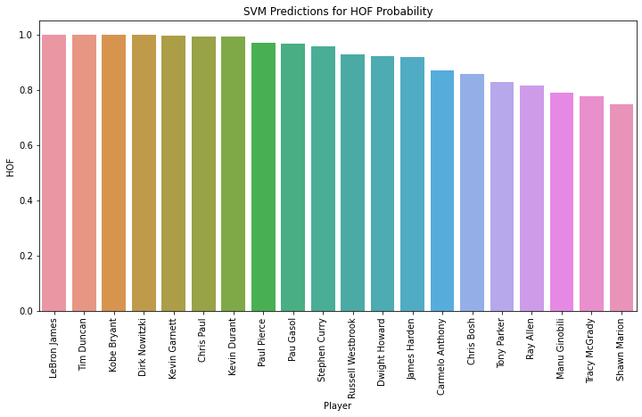

```python
plt.figure(figsize=(12,6))
g = sns.barplot(x = svm_results_hof.Player, y = svm_results_hof.HOF)
g.set_xticklabels(labels = svm_results_hof.Player,  rotation=90)
plt.title('SVM Predictions for HOF Probability')
plt.show()
```

## Neural Networks

When thinking about what models to use for sports prediction, neural networks were a clear choice. Neural networks have been used and have been shown to be potentially effective tools to predict outcomes in sports, and especially basketball. These this study (https://cs230.stanford.edu/projects_winter_2020/reports/32643049.pdf) and (https://www.researchgate.net/publication/24015640_Predicting_NBA_Games_Using_Neural_Networks) are a few examples, just to name a few.

It is common however for neural networks, especially when it comes to deep learning approaches, to be quite large and complex, but let’s see if a small and simple network can be somewhat performant as well. The first step is to come up with an architecture to use. We did not want our architecture to be a bottleneck, so we decided to test out two different model architectures of different philosophies to see if either would have an effect. The first architecture takes the feature space provided and expands it (the first hidden layer is larger than the feature vector) before compressing and the second architecture condenses it to start out with. Both are two-layer neural networks with sigmoid activation functions for the hidden layers and a softmax activation for the output layer.

```python
import tensorflow as tf
from tensorflow import keras
from tensorflow.keras import layers
```

[output not shown]

Before jumping into training our Neural Network, there were some things that needed to be addressed first. This particular use case is a non-standard application of a neural network. We are using historical data that could (and has) change. For example Kobe Bryant was not a Hall of Famer when this data was gathered, but he is now. As a result, we cannot really have a test dataset. We are simply training the model on past data and asking it to pick data points it would think to be most similar. As a result, we have no way of telling if the model is overfit with this approach.

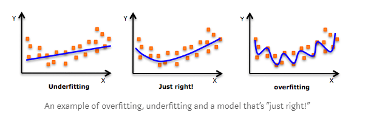

```python
sum(career_num.HOF)
```

```
74.0
```

```python
sum(hall_of_fame["HOF"])/len(hall_of_fame["HOF"])
```

```
0.07017191112898362
```

```python
def gen_noised_true():
    true_examples = career_num[career_num.HOF > 0].drop(["id", "Last_Season", "HOF"], axis = 1)
    for col in true_examples.columns:
        noise = np.random.normal(0,true_examples[col].std()/10, size=true_examples[col].shape)
        true_examples[col] = true_examples[col] + noise
    return true_examples

X_train_nn = X

num_add = 0 # change this number to add noised examples of HOF inductees
            # added to help reduce overfitting, but it potentially made it worse
for x in range(num_add):
    X_train_nn = X_train_nn.append(gen_noised_true(), ignore_index=True)


X_train_nn = X_train_nn.drop(["id", "Last_Season"], axis=1)
y_train_nn = y
for x in range(num_add):
    y_train_nn = y_train_nn.append(pd.Series(num_add*len(gen_noised_true())*[1.0]), ignore_index=True)

idx = np.random.permutation(X_train_nn.index)
X_train_nn.reindex(idx)
y_train_nn.reindex(idx)

X_test_nn_with_ids = X_test
X_test_nn = X_test.drop(["id", "Last_Season"], axis=1)
for col in X_train_nn.columns: # standardizing the input to feed the Neural Network
    X_test_nn[col] = ( X_test_nn[col] - X_test_nn[col].mean() ) / X_test_nn[col].std()
    X_train_nn[col] = ( X_train_nn[col] - X_train_nn[col].mean() ) / X_train_nn[col].std()
```

```python
X_train_nn
```

|  | PER | TS% | OWS | DWS | WS | WS/48 | OBPM | DBPM | BPM | FG% | ... | FT% | PPG | APG | RPG | SPG | BPG | Nb_MVP | Total_Champion | season | Total_PTS |
| --- | --- | --- | --- | --- | --- | --- | --- | --- | --- | --- | --- | --- | --- | --- | --- | --- | --- | --- | --- | --- | --- |
| 0 | 0.586241 | -0.181531 | 0.525134 | -0.486544 | 0.184478 | -0.191230 | 0.949699 | -1.877385 | -0.453677 | -0.620251 | ... | 1.845121 | 1.256092 | 0.984271 | -0.920509 | 0.152461 | -0.761236 | -0.119256 | -0.422623 | 0.295425 | 0.497053 |
| 8 | 0.345556 | -0.093608 | 0.277031 | -1.082618 | -0.237344 | 0.222464 | 0.574734 | -1.102811 | -0.249357 | -0.374543 | ... | 0.859249 | 0.061329 | 0.011166 | -0.785675 | -0.539560 | -0.572555 | -0.119256 | -0.422623 | 0.780605 | 0.494172 |
| 17 | 0.248356 | -0.329676 | 1.007243 | 1.095952 | 1.224414 | 0.772917 | 0.574734 | 0.102081 | 0.530775 | -0.720263 | ... | 1.134376 | 0.601976 | 2.559737 | -0.085027 | 0.608068 | -0.814175 | 2.601947 | 0.693991 | 1.508374 | 3.574522 |
| 18 | 2.905146 | 0.100305 | 0.237561 | -0.344120 | 0.040390 | 1.873821 | 3.092355 | 0.235958 | 2.697807 | -0.486902 | ... | 1.111449 | 2.210703 | 2.732875 | -0.187711 | 4.183246 | 0.530158 | -0.119256 | 0.693991 | 1.508374 | 3.317233 |
| 19 | 1.366152 | 0.403821 | 1.096053 | -0.344120 | 0.654329 | 0.904547 | 1.779978 | -0.366488 | 1.224225 | -0.357257 | ... | 0.555462 | 0.335640 | 1.904011 | -0.586705 | 0.957132 | -0.564951 | -0.119256 | -0.422623 | 1.750964 | 2.059601 |
| ... | ... | ... | ... | ... | ... | ... | ... | ... | ... | ... | ... | ... | ... | ... | ... | ... | ... | ... | ... | ... | ... |
| 1717 | 0.429795 | -0.547196 | -0.212408 | 1.007332 | 0.242113 | 0.155453 | 0.424748 | 1.280198 | 1.163548 | -0.481716 | ... | -0.523266 | 0.234164 | 0.499222 | 0.487838 | 1.371746 | -0.083963 | -0.119256 | -0.422623 | 0.052835 | -0.205831 |
| 1718 | 1.074553 | 0.467053 | 0.000735 | -0.676444 | -0.244653 | 1.299436 | 0.601517 | 0.302896 | 0.682467 | 1.146625 | ... | -0.361629 | -0.771674 | -1.017560 | -0.286522 | -1.139034 | 0.555866 | -0.119256 | -0.422623 | -0.917525 | -0.741256 |
| 1722 | 1.714451 | 1.750672 | 2.043355 | 0.458997 | 1.695832 | 1.520814 | 1.860328 | -0.015061 | 1.484269 | 0.187252 | ... | 1.581458 | 0.826897 | 3.094192 | -0.428057 | 3.229473 | -0.360965 | -0.119256 | 0.693991 | 0.538015 | -0.184305 |
| 1725 | -0.464441 | -0.380262 | -0.650535 | -1.064155 | -0.902444 | -1.309229 | -0.201979 | -1.303627 | -1.007818 | -0.811014 | ... | 0.566926 | -0.269040 | 1.930057 | -0.859626 | 0.686044 | -0.705057 | -0.119256 | -0.422623 | -1.402704 | -0.729053 |
| 1726 | 0.334756 | 0.800077 | -0.295297 | 0.394379 | -0.061933 | 0.645276 | -0.282328 | 1.507789 | 0.747478 | 1.397272 | ... | -1.112497 | -0.589977 | -1.027226 | 0.358705 | 0.052807 | 1.655959 | -0.119256 | -0.422623 | -0.917525 | -0.676680 |

753 rows × 23 columns

```python
y_train_nn
```

```
0       0.0
8       0.0
17      1.0
18      1.0
19      1.0
       ...
1717    0.0
1718    0.0
1722    0.0
1725    0.0
1726    0.0
Name: HOF, Length: 753, dtype: float64
```

```python
model1 = tf.keras.Sequential([
# Adds a densely-connected layer with 64 units to the model:
layers.Dense(64, activation='sigmoid', input_shape=(X_train_nn.shape[1],)),
# Add another:
layers.Dense(32, activation='sigmoid'),
# Add a softmax layer with 2 output units:
layers.Dense(2, activation='softmax')])

model1.compile(
    optimizer=keras.optimizers.Adam(learning_rate=1e-3),  # Optimizer
    # Loss function to minimize
    loss=keras.losses.SparseCategoricalCrossentropy(),
    # List of metrics to monitor
    metrics=[keras.metrics.SparseCategoricalAccuracy()],
)

model2 = tf.keras.Sequential([
# Adds a densely-connected layer with 10 units to the model:
layers.Dense(10, activation='sigmoid', input_shape=(X_train_nn.shape[1],)),
# Add another:
layers.Dense(5, activation='sigmoid'),
# Add a softmax layer with 1 output units:
layers.Dense(2, activation='softmax')])

model2.compile(
    optimizer=keras.optimizers.Adam(learning_rate=1e-3),  # Optimizer
    # Loss function to minimize
    loss=keras.losses.SparseCategoricalCrossentropy(),
    # List of metrics to monitor
    metrics=[keras.metrics.SparseCategoricalAccuracy()],
)
```

[output not shown]

We then started to play around with the hyperparameters. We found that the loss for the neural networks stopped decreasing greatly after 5 epochs, so we decided to stop the training there to prevent further overfitting. (The confidence for 10 epochs was really high). A batch size of 32 also lead to a reproducable and smooth decrease in loss.

```python
model1.fit(X_train_nn, y_train_nn, batch_size = 32, epochs = 5)
```

```
<keras.callbacks.History at 0x7f20d85b39d0>
```

```python
model2.fit(X_train_nn, y_train_nn, batch_size=32, epochs = 5)
```

```
<keras.callbacks.History at 0x7f20d831e880>
```

```python
nn_result1 = model1.predict(X_test_nn)
nn_result2 = model2.predict(X_test_nn)
```

```python
sort_inds_nn_1 = np.argsort(nn_result1[:,1])
nn_pred_inds_1 = sort_inds_nn_1[-20:][::-1]
nn_pred_ids_1 = X_test_nn_with_ids.iloc[nn_pred_inds_1]["id"]

sort_inds_nn_2 = np.argsort(nn_result2[:,1])
nn_pred_inds_2 = sort_inds_nn_2[-20:][::-1]
nn_pred_ids_2 = X_test_nn_with_ids.iloc[nn_pred_inds_2]["id"]
```

```python
nn_pred_ids_1
```

```
565     1675
752     2031
260     1151
590     1721
25       578
265     1157
983     2479
331     1262
623     1778
515     1591
1722    4396
483     1524
23       569
145      938
185     1031
274     1169
17       525
571     1684
381     1344
372     1331
Name: id, dtype: int64
```

```python
y_pred_proba_nn_1 = []
for i in range(len(nn_pred_ids_1)):
    y_pred_proba_nn_1.append(nn_result1[nn_pred_inds_1][i][1])
y_pred_proba_nn_1 = np.asarray(y_pred_proba_nn_1)

results_hof_nn_1 = pd.DataFrame({
    "id": nn_pred_ids_1,
    "HOF": y_pred_proba_nn_1
    })
results_hof_nn_1

y_pred_proba_nn_2 = []
for i in range(len(nn_pred_ids_2)):
    y_pred_proba_nn_2.append(nn_result2[nn_pred_inds_2][i][1])
y_pred_proba_nn_2 = np.asarray(y_pred_proba_nn_2)

results_hof_nn_2 = pd.DataFrame({
    "id": nn_pred_ids_2,
    "HOF": y_pred_proba_nn_2
    })
```

```python
career_player_nn_1 = career[['id', 'Player']]
results_hof_nn_1 = career_player.merge(results_hof_nn_1, on='id')

results_hof_nn_1 = results_hof_nn_1.sort_values(by='HOF', ascending=False)
results_hof_nn_1 = results_hof_nn_1.head(20)

career_player_nn_2 = career[['id', 'Player']]
results_hof_nn_2 = career_player.merge(results_hof_nn_2, on='id')

results_hof_nn_2 = results_hof_nn_2.sort_values(by='HOF', ascending=False)
results_hof_nn_2 = results_hof_nn_2.head(20)
```

```python
results_hof_nn_1
```

|  | id | Player | HOF |
| --- | --- | --- | --- |
| 14 | 1675 | Michael Jordan* | 0.525593 |
| 18 | 2031 | David Robinson* | 0.516897 |
| 5 | 1151 | Julius Erving* | 0.446543 |
| 16 | 1721 | Patrick Ewing* | 0.375375 |
| 2 | 578 | John Havlicek* | 0.360123 |
| 6 | 1157 | George Gervin* | 0.335421 |
| 19 | 2479 | Allen Iverson* | 0.333528 |
| 8 | 1262 | Bernard King* | 0.314367 |
| 17 | 1778 | Brad Daugherty | 0.308145 |
| 13 | 1591 | James Worthy* | 0.306450 |
| 20 | 4396 | Micheal Williams | 0.282265 |
| 12 | 1524 | Buck Williams | 0.280871 |
| 1 | 569 | Dave DeBusschere* | 0.277948 |
| 3 | 938 | Walter Davis | 0.266991 |
| 4 | 1031 | John Drew | 0.253597 |
| 7 | 1169 | Dennis Johnson* | 0.235304 |
| 0 | 525 | Oscar Robertson* | 0.225163 |
| 15 | 1684 | Alvin Robertson | 0.224746 |
| 11 | 1344 | Bill Cartwright | 0.214703 |
| 9 | 1331 | Reggie Theus | 0.208610 |

```python
results_hof_nn_2
```

|  | id | Player | HOF |
| --- | --- | --- | --- |
| 15 | 1675 | Michael Jordan* | 0.570374 |
| 18 | 2031 | David Robinson* | 0.555130 |
| 6 | 1151 | Julius Erving* | 0.553112 |
| 2 | 578 | John Havlicek* | 0.549940 |
| 1 | 569 | Dave DeBusschere* | 0.549896 |
| 16 | 1721 | Patrick Ewing* | 0.545014 |
| 7 | 1157 | George Gervin* | 0.541477 |
| 5 | 1031 | John Drew | 0.538928 |
| 0 | 525 | Oscar Robertson* | 0.538792 |
| 14 | 1591 | James Worthy* | 0.537899 |
| 11 | 1344 | Bill Cartwright | 0.536611 |
| 3 | 690 | Bob Love | 0.536468 |
| 19 | 2479 | Allen Iverson* | 0.535036 |
| 9 | 1184 | Maurice Lucas | 0.534904 |
| 8 | 1169 | Dennis Johnson* | 0.534833 |
| 10 | 1262 | Bernard King* | 0.532182 |
| 13 | 1524 | Buck Williams | 0.528184 |
| 17 | 1778 | Brad Daugherty | 0.527861 |
| 4 | 938 | Walter Davis | 0.523691 |
| 12 | 1384 | Cliff Robinson | 0.523254 |

Here are graph representations of the previous table data.

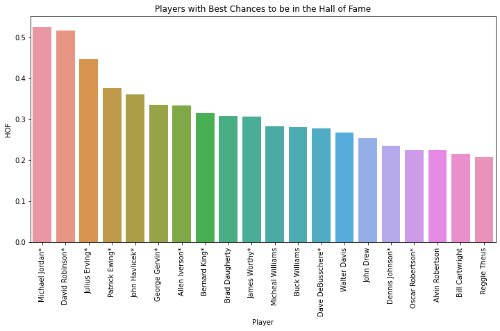

```python
plt.figure(figsize=(12,6))
g = sns.barplot(x = results_hof_nn_1.Player, y = results_hof_nn_1.HOF)
g.set_xticklabels(labels = results_hof_nn_1.Player,  rotation=90)
plt.title('Players with Best Chances to be in the Hall of Fame')
plt.show()
```

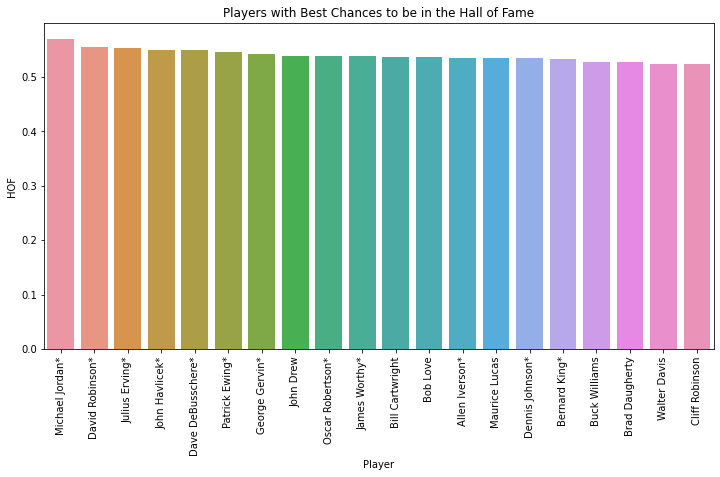

```python
plt.figure(figsize=(12,6))
g = sns.barplot(x = results_hof_nn_2.Player, y = results_hof_nn_2.HOF)
g.set_xticklabels(labels = results_hof_nn_2.Player,  rotation=90)
plt.title('Players with Best Chances to be in the Hall of Fame')
plt.show()
```

## Decision Tree

Next we attempted a decision tree

```python
from sklearn import tree
from sklearn.model_selection import train_test_split
# train : older players who stop playing 20+ years ago (last data year is 2017 so 1997)
train = career_num[(career_num.Last_Season <= 1997) | (career_num.HOF == 1)]
test = career_num[(career_num.Last_Season > 1997) & (career_num.HOF == 0)]

X_train = train.drop('HOF', axis=1)
y_train = train['HOF']
X_test = test.drop('HOF', axis=1)
```

[output not shown]

[figure not shown]

```python
# Decision Tree

dt = tree.DecisionTreeClassifier()
dt.fit(X_train, y_train)
y_pred = dt.predict(X_test)
dt.score(X_train, y_train)
acc_dt = round(dt.score(X_train, y_train) * 100, 2)

tree.plot_tree(dt)
```

In the Code above, we use sklearns tree in order to train a decision tree. As you can see above, the tree is fairly large due to the amount of variables it has to consider in order to get to its result.

```python
pred_proba = dt.predict_proba(X_test)

y_pred_proba = []
for i in enumerate(pred_proba):
    y_pred_proba.append(i[1][1])
y_pred_proba = np.asarray(y_pred_proba)

results_hof = pd.DataFrame({
    "id": test["id"],
    "HOF": y_pred_proba
    })


career_player = career[['id', 'Player']]
results_hof = career_player.merge(results_hof, on='id')

results_hof = results_hof.sort_values(by='HOF', ascending=False)
results_hof = results_hof.head(20)
results_hof
```

|  | id | Player | HOF |
| --- | --- | --- | --- |
| 84 | 1970 | Dana Barros | 1.0 |
| 606 | 3096 | Chris Paul | 1.0 |
| 940 | 3745 | Julius Randle | 1.0 |
| 217 | 2337 | Jason Kidd | 1.0 |
| 835 | 3545 | Andre Drummond | 1.0 |
| 455 | 2808 | Pau Gasol | 1.0 |
| 718 | 3325 | Russell Westbrook | 1.0 |
| 464 | 2816 | Richard Jefferson | 1.0 |
| 341 | 2607 | Antawn Jamison | 1.0 |
| 467 | 2823 | Tony Parker | 1.0 |
| 960 | 3790 | Nikola Jokic | 1.0 |
| 80 | 1950 | Rony Seikaly | 1.0 |
| 603 | 3088 | Sean May | 1.0 |
| 108 | 2023 | Joe Johnson | 1.0 |
| 241 | 2399 | Michael Finley | 1.0 |
| 973 | 3824 | Karl-Anthony Towns | 1.0 |
| 243 | 2399 | Rashard Lewis | 1.0 |
| 485 | 2849 | Carlos Boozer | 1.0 |
| 811 | 3491 | Kawhi Leonard | 1.0 |
| 245 | 2401 | Kevin Garnett | 1.0 |

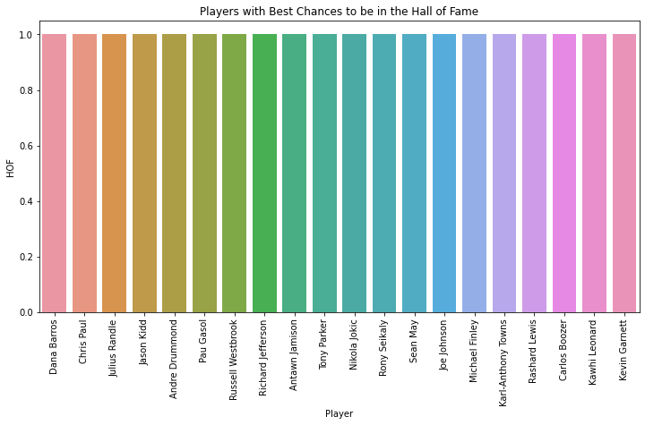

```python
plt.figure(figsize=(12,6))
g = sns.barplot(x = results_hof.Player, y = results_hof.HOF)
g.set_xticklabels(labels = results_hof.Player,  rotation=90)
plt.title('Players with Best Chances to be in the Hall of Fame')
plt.show()
```

Looking at our end results for the decision tree, we can see that while we do get a result for who will and who will not be in the Hall of Fame, these results don't give us anything that can be used beyond just 'yes' or 'no'. With the other classifiers, we get a percentage chance for Hall of Fame status, which is a much more useful metric to evaluate who potential Hall of Famers. Simply know whether or not some can make it to the Hall of Fame will not help a company choose a potential player to sponsor, whereas knowing a player has 92% chance to make it to the Hall of Fame definitely will help a company choose. This goes to show that not all classifiers are going to provide results that matter for all types of problems. In this case, while a decision tree does the job, it just doesn't perform at the same level as the three other algorithms, because there's no way to really compare the results from the Decision Tree.

For further reading into why Decision Trees are not optimal, the link:( https://careerfoundry.com/en/blog/data-analytics/what-is-a-decision-tree/#:~:text=Disadvantages%20of%20decision%20trees,-Overfitting%20(where%20a&text=They%20are%20not%20well%2Dsuited,path%20includes%20many%20chance%20variables. ), was very informative for me when I was trying to interpret the results of the decision tree.

## KNN

To run the KNN model, we took a look at KNeighborsClassifer from the sklearn library. After analysis and testing of prediction percentage on the number of neighbors helps classify, we found that 22 neighbors was a prediction that got enough of the neighbors to make an accurate prediction

```python
from sklearn.neighbors import KNeighborsClassifier
knn = KNeighborsClassifier(n_neighbors=22)
```

Similar to the other models, we decided that we will have the training data of players who stopped playing 20 years ago based on the last data year, which was 2017. The players represented in the test data are those who are either playing or recently retired

```python
knn_train = career_num[(career_num.Last_Season <= 1997) | (career_num.HOF == 1)]
knn_test = career_num[(career_num.Last_Season > 1997) & (career_num.HOF == 0)]
```

```python
knn_X_train = knn_train.drop('HOF', axis=1)
knn_y_train = knn_train['HOF']
knn_X_test = knn_test.drop('HOF', axis=1)
```

Using the KNN that we initialized earlier, we can fit our training data so we can use the correlation amongst the X and y training, to predict Hall of Fame possibilities from our test data. This fitting is represented in the first line, and the prediction is in the second line. The third line tells us how well the KNN fitting actually did.

```python
knn.fit(knn_X_train, knn_y_train)
knn_y_pred = knn.predict(knn_X_test)
knn.score(knn_X_train, knn_y_train)
```

```
0.9455511288180611
```

Predicted probability in the context will be the chance that a player from the test data makes it into the Hall of Fame. We use this predicted probability to make a prediction as noted with y_pred_proba. After we get our result, we will match the given IDs to the HOF percentage the player would get based on their neighbors

```python
pred_proba = knn.predict_proba(knn_X_test)
```

```python
y_pred_proba = []
for i in enumerate(pred_proba):
    y_pred_proba.append(i[1][1])
y_pred_proba = np.asarray(y_pred_proba)
results_hof = pd.DataFrame({
    "id": knn_X_test["id"],
    "HOF": y_pred_proba
    })
```

The next few lines of code represent the tying of all the data to the real life players who represent the data. The first line combines the career players stats to the respective player it represents. The next few lines gives us the combined list, and we decided to sort by HOF chances as this is the information we are looking to gather

```python
career_player = career[['id', 'Player']]
results_hof = career_player.merge(results_hof, on='id')

results_hof = results_hof.sort_values(by='HOF', ascending=False)
results_hof = results_hof.head(12)
results_hof
```

|  | id | Player | HOF |
| --- | --- | --- | --- |
| 266 | 2456 | Kobe Bryant | 1.000000 |
| 531 | 2944 | LeBron James | 1.000000 |
| 357 | 2626 | Dirk Nowitzki | 1.000000 |
| 301 | 2535 | Tim Duncan | 0.954545 |
| 245 | 2401 | Kevin Garnett | 0.954545 |
| 360 | 2630 | Paul Pierce | 0.954545 |
| 1 | 58 | Ray Allen | 0.954545 |
| 516 | 2907 | Carmelo Anthony | 0.954545 |
| 108 | 2023 | Joe Johnson | 0.818182 |
| 455 | 2808 | Pau Gasol | 0.818182 |
| 341 | 2607 | Antawn Jamison | 0.818182 |
| 41 | 1538 | Terry Cummings | 0.772727 |

To best show our results, we took the top 12 players and decided to graph it out to show the percentage chance of them making the HOF.

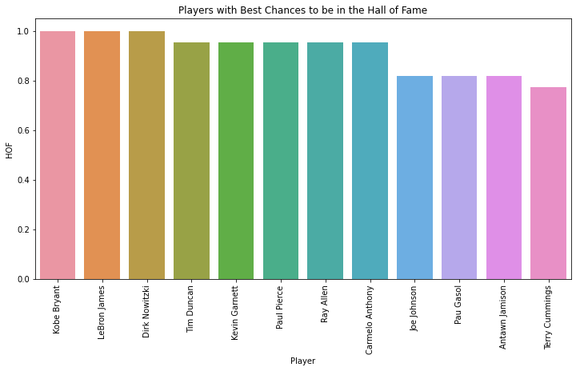

```python
plt.figure(figsize=(12,6))
g = sns.barplot(x = results_hof.Player, y = results_hof.HOF)
g.set_xticklabels(labels = results_hof.Player,  rotation=90)
plt.title('Players with Best Chances to be in the Hall of Fame')
plt.show()
```

The graph correlates with some of the other models we have used, and the intuition of most NBA fans, giving us confidence that using a KNN model can be of good use in prediction of possible players to make the HOF. By gaining high percentage chances with the top 10 players having over 80% confidence of making the Hall of Fame, we can say that using the KNN model is beneficial in using analytics as a measure of success, rather than only the eye test.

An article that helped give us more perspective and growth towards modeling and predictions in the NBA is: https://medium.com/kenyon-college-sports-analytics/using-knn-methods-to-predict-cavs-outcomes-based-on-halftime-data-b809b2d47ae6 which covered how by using KNN, it would be possible to add addtional confidence in stats and game scores on certain games.

## Future Work

In future work, we would like to further investigate the relationships between the models. For example, we would like to know which features are most strongly correlated with the difference in the model predictions; i.e. do certain models weigh a given feature more heavily than others, and are therefore more likely to predict different players? We would also like to consider applying data augmentation techniques; while there are hundreds of Hall of Fame inductees over time, there is still a relatively small number of them especially with respect to the total all-time NBA player base as a whole. With data augmentation, we could generate artificial “new” data which could potentially improve the robustness of our prediction models. Finally, we are also curious about the potential applications of similar models to other sports. For example, baseball is another sport with a great deal of publicly available statistics (e.g https://www.kaggle.com/datasets/open-source-sports/baseball-databank). We could apply the same techniques to other sports and make similar predictions.